# Biketown Data Cleanup

Load the packages we’ll need:

```r
library(ggplot2)
library(dplyr)
library(tidyr)
library(tidyverse)
```

Load the dataframe as ‘df’:

```r
df = readRDS("C:\\Users\\ccrisp\\Documents\\Biketown Data\\Biketown.rds")
```

View the summary:

```r
summary(df)
```

```
##     RouteID         PaymentPlan          StartHub         StartLatitude
##  Min.   : 1282087   Length:1294447     Length:1294447     Min.   :45.30
##  1st Qu.: 3707796   Class :character   Class :character   1st Qu.:45.52
##  Median : 7598896   Mode  :character   Mode  :character   Median :45.52
##  Mean   : 7502268                                         Mean   :45.52
##  3rd Qu.:11378053                                         3rd Qu.:45.53
##  Max.   :13531535                                         Max.   :45.73
##  NA's   :4088                                             NA's   :4681
##  StartLongitude      StartDate           StartTime           EndHub
##  Min.   :-123.14   Min.   :2016-07-19   Length:1294447    Length:1294447
##  1st Qu.:-122.68   1st Qu.:2017-07-21   Class1:hms        Class :character
##  Median :-122.67   Median :2018-06-16   Class2:difftime   Mode  :character
##  Mean   :-122.67   Mean   :2018-06-06   Mode  :numeric
##  3rd Qu.:-122.66   3rd Qu.:2019-05-10
##  Max.   :  67.18   Max.   :2020-08-31
##  NA's   :4681      NA's   :4088
##   EndLatitude     EndLongitude       EndDate             EndTime
##  Min.   :34.26   Min.   :-134.4   Min.   :1969-12-31   Length:1294447
##  1st Qu.:45.52   1st Qu.:-122.7   1st Qu.:2017-07-21   Class1:hms
##  Median :45.52   Median :-122.7   Median :2018-06-16   Class2:difftime
##  Mean   :45.52   Mean   :-122.7   Mean   :2018-06-06   Mode  :numeric
##  3rd Qu.:45.53   3rd Qu.:-122.7   3rd Qu.:2019-05-10
##  Max.   :49.16   Max.   :  45.5   Max.   :2080-01-05
##  NA's   :4731    NA's   :4731     NA's   :4394
##    TripType             BikeID        BikeName         Distance_Miles
##  Length:1294447     Min.   : 5986   Length:1294447     Min.   :    0.000
##  Class :character   1st Qu.: 6302   Class :character   1st Qu.:    0.720
##  Mode  :character   Median : 6574   Mode  :character   Median :    1.310
##                     Mean   : 6982                      Mean   :    2.036
##                     3rd Qu.: 7155                      3rd Qu.:    2.420
##                     Max.   :35537                      Max.   :15527.180
##                     NA's   :4088                       NA's   :4088
##    Duration         RentalAccessPath   MultipleRental
##  Length:1294447     Length:1294447     Mode :logical
##  Class :character   Class :character   FALSE:1170921
##  Mode  :character   Mode  :character   TRUE :119438
##                                        NA's :4088
##
##
##
```

Let’s look at each field:

```r
table(df$PaymentPlan)
```

```
##
##                Casual Subscriber
##       4088     753396     536963
```

Only 2 types, Casual and Subscriber, plus 4088 blank (or NA?) values. WHERE ARE ALL THE NA’S COMING FROM? I can’t find them in the data!

Let’s look at the Start Hub counts. *[I did this and there are just a ton; it took a while to scroll through them all.]*

```r
#table(df$StartHub)

#get the number of unique hubs:
length(unique(df$StartHub))
```

```
## [1] 233
```

Let’s look at the 10 most popular Start Hubs:

```r
head(sort(table(df$StartHub), decreasing = TRUE), 10)
```

```
##
##                                      SW Salmon at Waterfront Park
##                           395416                            29212
## SW Moody at Aerial Tram Terminal           SW River at Montgomery
##                            21178                            19000
##               NW Everett at 22nd              NW 13th at Marshall
##                            18362                            18168
##                 SW 3rd at Ankeny                 NW Couch at 11th
##                            15848                            15683
##              SW Morrison at 18th         SW Naito at Ankeny Plaza
##                            15631                            15184
```

Looks like a very large number of bikes don’t start at a hub.

Let’s check the Start Latitude and Start Longitude:

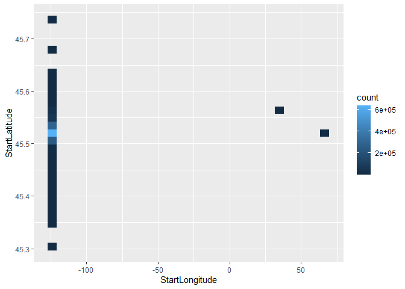

```r
ggplot(data = df, aes(x = StartLongitude, y = StartLatitude)) +
  geom_bin2d()
```

Let’s take a look at some of the extreme values (ignoring NAs):

```r
range(df$StartLatitude, na.rm = TRUE)
```

```
## [1] 45.30201 45.73409
```

```r
range(df$StartLongitude, na.rm = TRUE)
```

```
## [1] -123.13987   67.18144
```

Looks like all bike rides started between the 45.3 and 45.73 parallel. However, there are two outliers in the longitude:

```r
df[which(df$StartLongitude > 0),]
```

```
##         RouteID PaymentPlan StartHub StartLatitude StartLongitude  StartDate
## 894634 10753147  Subscriber               45.51789       67.18144 2019-02-07
## 988408 11468802  Subscriber               45.56278       33.92405 2019-05-23
##        StartTime EndHub EndLatitude EndLongitude    EndDate  EndTime TripType
## 894634  07:51:00           45.51750    -122.6926 2019-02-07 07:53:00
## 988408  13:01:00           45.56269    -122.6750 2019-05-23 13:44:00
##        BikeID          BikeName Distance_Miles Duration RentalAccessPath
## 894634   6650     0814 BIKETOWN        6125.21  0:02:24           mobile
## 988408   7206 0553 MSS BIKETOWN        5990.42  0:43:25 keypad_rfid_card
##        MultipleRental
## 894634          FALSE
## 988408          FALSE
```

The duration of the trip is clearly too short to allow for that distance to be covered, so there must have been a problem with the GPS system. I think we should exclude these two trips from the analysis, or perhaps impute a more realistic distance.

Here’s what the 2D histogram looks like if we remove those 2 outliers:

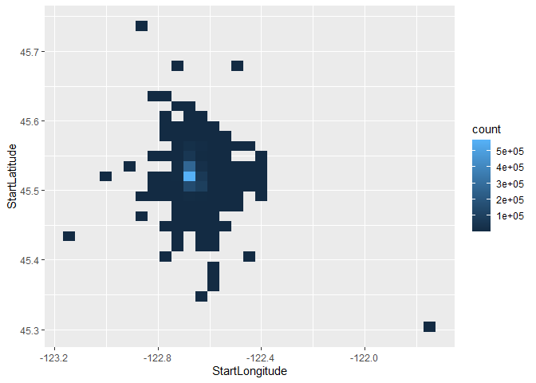

```r
ggplot(data = df[which(df$StartLongitude < 0),], aes(x = StartLongitude, y = StartLatitude)) +
  geom_bin2d()
```

Let’s check the ending coordinates now:

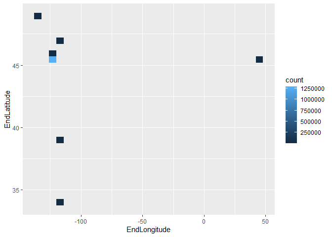

```r
ggplot(data = df, aes(x = EndLongitude, y = EndLatitude)) +
  geom_bin2d()
```

We’ve got some outliers here. Let’s look at those:

```r
df[which(df$EndLatitude < 45 | df$EndLatitude > 47 | df$EndLongitude > -100), ]
```

```
##          RouteID PaymentPlan                    StartHub StartLatitude
## 205179   2712719  Subscriber SW Yamhill at Director Park      45.51898
## 205618   2719516      Casual                                  45.54953
## 862135  10418294  Subscriber                                  45.52640
## 870228  10503880  Subscriber             SW 12th at Clay      45.51507
## 1176773 12730762  Subscriber                                  45.52640
##         StartLongitude  StartDate StartTime EndHub EndLatitude EndLongitude
## 205179       -122.6813 2017-04-24  15:30:00           49.16000   -134.43000
## 205618       -122.6680 2017-04-25  14:41:00           34.26000   -118.60000
## 862135       -122.6894 2018-12-04  05:40:00           38.89229   -118.16594
## 870228       -122.6870 2018-12-19  14:24:00           45.52466     45.50117
## 1176773      -122.6894 2019-11-13  06:36:00           47.00627   -119.43678
##            EndDate  EndTime TripType BikeID                 BikeName
## 205179  2017-04-25 09:34:00            6852            0820 BIKETOWN
## 205618  2017-05-03 13:57:00            6504 0835 BIKETOWN - HBO BIKE
## 862135  2018-12-04 09:00:00            6874            0862 BIKETOWN
## 870228  2018-12-19 14:43:00            6059            0816 BIKETOWN
## 1176773 2019-11-13 10:05:00            6891            0686 BIKETOWN
##         Distance_Miles  Duration RentalAccessPath MultipleRental
## 205179         1429.65  18:03:50           keypad          FALSE
## 205618          865.49 191:15:35 keypad_rfid_card           TRUE
## 862135          561.12   3:20:29 keypad_rfid_card          FALSE
## 870228         6113.09   0:19:14 keypad_rfid_card          FALSE
## 1176773         324.51   3:29:08           keypad          FALSE
```

- The first one (RouteID = 2712719) averaged a speed of about 79 mph, so clearly not realistic.
- The second one (Route ID = 2719516) averaged about 4.5 mph, which sounds realistic if you’re considering breaks during that 191 hour trip.
- The 3rd one would require physically impossible speeds for a biker (about 170 mph), so either something happened to GPS or somebody took the bike on an airplane.
- The 4th one would require speeds many times faster than the speed of sound, so that one should probably be removed.
- The 5th one also requires a speed that’s much too fast (about 92.7 mph).

Here’s what the distribution would look like without those 5 outliers:

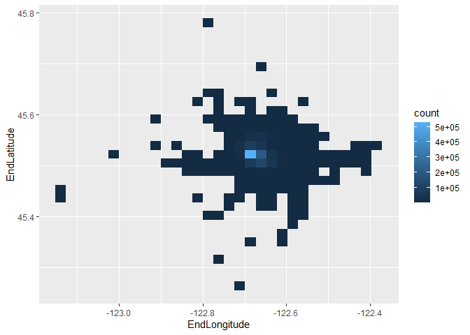

```r
ggplot(data = df[which(df$EndLatitude > 45 & df$EndLatitude < 47 & df$EndLongitude < -100), ], aes(x = EndLongitude, y = EndLatitude)) +
  geom_bin2d()
```

Seems reasonable.

Let’s check the range and distribution of start dates:

```r
range(df$StartDate, na.rm = TRUE)
```

```
## [1] "2016-07-19" "2020-08-31"
```

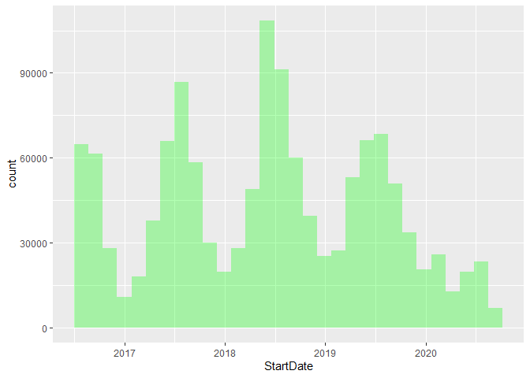

```r
ggplot(data = df, aes(x = StartDate)) +
  geom_histogram(fill = alpha("green", 0.3))
```

This all looks reasonable. Note that summer of 2018 seemed to be the peak, and there wasn’t much of a peak during summer 2020 (undoubtedly COVID-related).

Let’s also check the range and distribution of end dates:

```r
range(df$EndDate, na.rm = TRUE)
```

```
## [1] "1969-12-31" "2080-01-05"
```

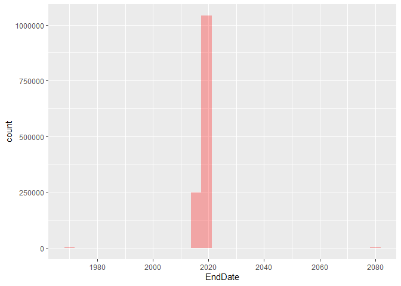

```r
ggplot(data = df, aes(x = EndDate)) +
  geom_histogram(fill = alpha("red", 0.3))
```

We have two extreme values here. Clearly the trip that ended in 1969 is problematic, as is the trip that ends in 2080. Let’s check all the records that ended outside of the Start Date range:

```r
df[which(df$EndDate < "2016-07-19" | df$EndDate > "2020-08-31"), ]
```

```
##          RouteID PaymentPlan                                    StartHub
## 178744   2463277  Subscriber
## 180316   2475238  Subscriber                         NW 18th at Northrup
## 184990   2522822  Subscriber                            SE Clay at Water
## 190596   2566711  Subscriber
## 193693   2596071  Subscriber
## 199127   2655418      Casual                SW Salmon at Waterfront Park
## 201320   2674282  Subscriber                        SE Ladd at Hawthorne
## 206278   2728455  Subscriber
## 256570   3126012  Subscriber
## 263048   3199331      Casual
## 263858   3209459      Casual                NW 8th at Everett - Disabled
## 264198   3214507  Subscriber
## 276308   3325520  Subscriber
## 278284   3338879  Subscriber
```

[output cut: 295 more lines]

There are a few trips that ended just after midnight on September 1, 2020, and I think they should be included. Here are the records we may want to toss (I’m not showing the output because it’s so long):

```r
df[which(df$EndDate < "2016-07-19" | df$EndDate > "2020-09-01"), ]
```

Here is the distribution of End Dates if we toss those days:

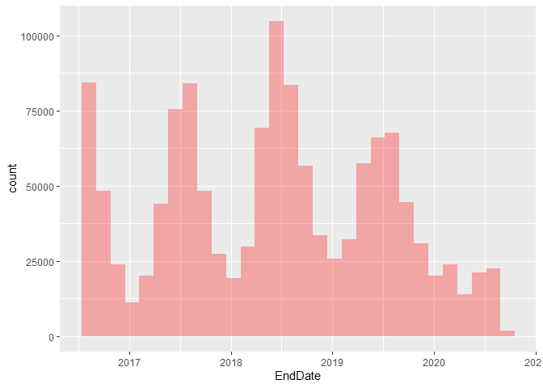

```r
ggplot(data = df[(df$EndDate >= "2016-07-19") & (df$EndDate <= "2020-09-01"), ],
       aes(x = EndDate)) +
  geom_histogram(fill = alpha("red", 0.3))
```

We see a similar pattern here compared to the Start Date histogram, which is fully expected.

Let’s look at the start times, using a circular histogram:

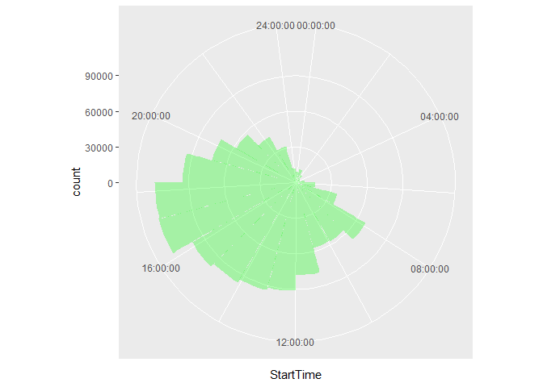

```r
ggplot(data = df, aes(x = StartTime)) +
  geom_histogram(bins = 24, fill = alpha("green", 0.3)) +
  coord_polar()
```

All looks reasonable. Same visualization with the EndTime:

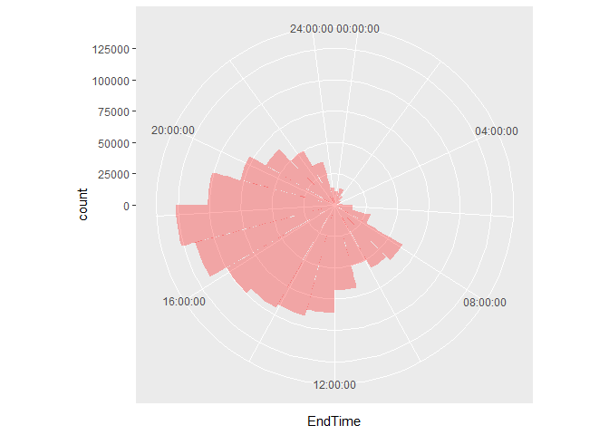

```r
ggplot(data = df, aes(x = EndTime)) +
  geom_histogram(bins = 24, fill = alpha("red", 0.3)) +
  coord_polar()
```

Let’s check the Trip Type:

```r
table(df$TripType)
```

```
##
##               commute     errand recreation       work
##    1293088        415        177        678         89
```

Looks like a very low percentage of riders respond to questions about the trip type. Probably not worth doing anything with this field.

Let’s check the distribution of distances:

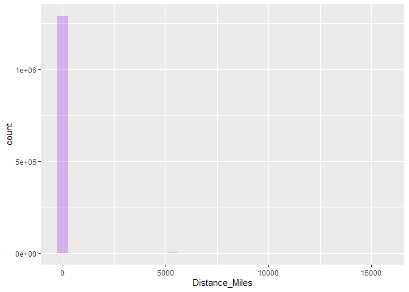

```r
ggplot(data = df, aes(x = Distance_Miles)) +
  geom_histogram(fill = alpha("purple", 0.3))
```

Let’s see what the biggest values are:

```r
head(sort(df$Distance_Miles, decreasing = TRUE), 10)
```

```
##  [1] 15527.18 11989.44 10398.01 10015.78  7764.97  6698.23  6307.82  6125.21
##  [9]  6113.09  5994.92
```

There are a lot of these. Let’s see how many “trips” were over 1000 miles:

```r
nrow(df[which(df$Distance_Miles > 1000),])
```

```
## [1] 39
```

I honestly don’t think we’re interested in these really long trips, since they are likely not real trips anyway (faulty GPS or perhaps bike was moved across the country). Let’s see what the distribution looks like if we toss out the trips over 1000 miles:

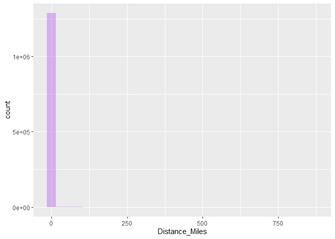

```r
ggplot(data = df[which(df$Distance_Miles < 1000),], aes(x = Distance_Miles)) +
  geom_histogram(fill = alpha("purple", 0.3))
```

Hmmm. Ok, let’s look at under 100 miles:

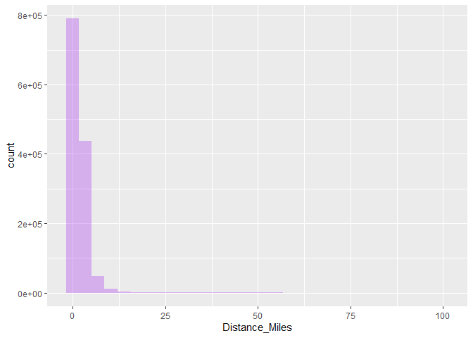

```r
ggplot(data = df[which(df$Distance_Miles < 100),], aes(x = Distance_Miles)) +
  geom_histogram(fill = alpha("purple", 0.3))
```

Let’s go even smaller - let’s look at under 25 miles:

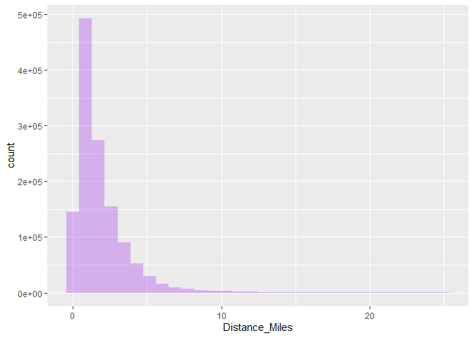

```r
ggplot(data = df[which(df$Distance_Miles < 25),], aes(x = Distance_Miles)) +
  geom_histogram(fill = alpha("purple", 0.3))
```

Looks like the vast majority are under 15 miles, which makes sense intuitively. Let’s see what percentage of trips are under 15 miles:

```r
nrow(df[which(df$Distance_Miles < 15), ]) / nrow(df)
```

```
## [1] 0.9952582
```

That’s over 99.5% of all trips, so I think we can just restrict ourselves to the trips under 15 miles.

### CLEANUP

```r
#get rid of trips over 15 miles in duration
df_clean = df[which(df$Distance_Miles < 15), ]
```

That one change removed 6138 trips.

```r
#get rid of problematic end dates
df_clean = df_clean[(df_clean$EndDate >= "2016-07-19") & (df_clean$EndDate <= "2020-09-01"), ]
```

That changed removed an additional 58 trips. Check to make sure the range is reasonable now:

```r
range(df_clean$EndDate, na.rm = TRUE)
```

```
## [1] "2016-07-19" "2020-09-01"
```

Looks good.

Now, let’s try to find where the NA values are:

```r
summary(df_clean)
```

```
##     RouteID         PaymentPlan          StartHub         StartLatitude
##  Min.   : 1282087   Length:1288251     Length:1288251     Min.   :45.37
##  1st Qu.: 3708168   Class :character   Class :character   1st Qu.:45.52
##  Median : 7598135   Mode  :character   Mode  :character   Median :45.52
##  Mean   : 7501850                                         Mean   :45.52
##  3rd Qu.:11377312                                         3rd Qu.:45.53
##  Max.   :13531535                                         Max.   :45.68
##  NA's   :306                                              NA's   :884
##  StartLongitude     StartDate           StartTime           EndHub
##  Min.   :-123.1   Min.   :2016-07-19   Length:1288251    Length:1288251
##  1st Qu.:-122.7   1st Qu.:2017-07-21   Class1:hms        Class :character
##  Median :-122.7   Median :2018-06-16   Class2:difftime   Mode  :character
##  Mean   :-122.7   Mean   :2018-06-06   Mode  :numeric
##  3rd Qu.:-122.7   3rd Qu.:2019-05-10
##  Max.   :-122.4   Max.   :2020-08-31
##  NA's   :884      NA's   :306
##   EndLatitude     EndLongitude       EndDate             EndTime
##  Min.   :45.35   Min.   :-123.1   Min.   :2016-07-19   Length:1288251
##  1st Qu.:45.52   1st Qu.:-122.7   1st Qu.:2017-07-21   Class1:hms
##  Median :45.52   Median :-122.7   Median :2018-06-16   Class2:difftime
##  Mean   :45.52   Mean   :-122.7   Mean   :2018-06-06   Mode  :numeric
##  3rd Qu.:45.53   3rd Qu.:-122.7   3rd Qu.:2019-05-10
##  Max.   :45.70   Max.   :-122.4   Max.   :2020-09-01
##  NA's   :935     NA's   :935      NA's   :306
##    TripType             BikeID        BikeName         Distance_Miles
##  Length:1288251     Min.   : 5986   Length:1288251     Min.   : 0.000
##  Class :character   1st Qu.: 6302   Class :character   1st Qu.: 0.720
##  Mode  :character   Median : 6574   Mode  :character   Median : 1.310
##                     Mean   : 6982                      Mean   : 1.846
##                     3rd Qu.: 7155                      3rd Qu.: 2.410
##                     Max.   :35537                      Max.   :14.990
##                     NA's   :306                        NA's   :306
##    Duration         RentalAccessPath   MultipleRental
##  Length:1288251     Length:1288251     Mode :logical
##  Class :character   Class :character   FALSE:1168794
##  Mode  :character   Mode  :character   TRUE :119151
##                                        NA's :306
##
##
##
```

The code chunk below will show all the trips with NA in the RouteID field. There are a lot of them, so I’m not going to print them here. But, I confirmed that ALL the other fields were also NA in those records. I wonder if somehow a bunch of NA records were created during the consolidation process.

```r
df_clean[(is.na(df_clean$RouteID)), ]
```

Let’s get rid of them.

```r
df_clean = df_clean[(!is.na(df_clean$RouteID)), ]
```

Check the summary now:

```r
summary(df_clean)
```

```
##     RouteID         PaymentPlan          StartHub         StartLatitude
##  Min.   : 1282087   Length:1287945     Length:1287945     Min.   :45.37
##  1st Qu.: 3708168   Class :character   Class :character   1st Qu.:45.52
##  Median : 7598135   Mode  :character   Mode  :character   Median :45.52
##  Mean   : 7501850                                         Mean   :45.52
##  3rd Qu.:11377312                                         3rd Qu.:45.53
##  Max.   :13531535                                         Max.   :45.68
##                                                           NA's   :578
##  StartLongitude     StartDate           StartTime           EndHub
##  Min.   :-123.1   Min.   :2016-07-19   Length:1287945    Length:1287945
##  1st Qu.:-122.7   1st Qu.:2017-07-21   Class1:hms        Class :character
##  Median :-122.7   Median :2018-06-16   Class2:difftime   Mode  :character
##  Mean   :-122.7   Mean   :2018-06-06   Mode  :numeric
##  3rd Qu.:-122.7   3rd Qu.:2019-05-10
##  Max.   :-122.4   Max.   :2020-08-31
##  NA's   :578
##   EndLatitude     EndLongitude       EndDate             EndTime
##  Min.   :45.35   Min.   :-123.1   Min.   :2016-07-19   Length:1287945
##  1st Qu.:45.52   1st Qu.:-122.7   1st Qu.:2017-07-21   Class1:hms
##  Median :45.52   Median :-122.7   Median :2018-06-16   Class2:difftime
##  Mean   :45.52   Mean   :-122.7   Mean   :2018-06-06   Mode  :numeric
##  3rd Qu.:45.53   3rd Qu.:-122.7   3rd Qu.:2019-05-10
##  Max.   :45.70   Max.   :-122.4   Max.   :2020-09-01
##  NA's   :629     NA's   :629
##    TripType             BikeID        BikeName         Distance_Miles
##  Length:1287945     Min.   : 5986   Length:1287945     Min.   : 0.000
##  Class :character   1st Qu.: 6302   Class :character   1st Qu.: 0.720
##  Mode  :character   Median : 6574   Mode  :character   Median : 1.310
##                     Mean   : 6982                      Mean   : 1.846
##                     3rd Qu.: 7155                      3rd Qu.: 2.410
##                     Max.   :35537                      Max.   :14.990
##
##    Duration         RentalAccessPath   MultipleRental
##  Length:1287945     Length:1287945     Mode :logical
##  Class :character   Class :character   FALSE:1168794
##  Mode  :character   Mode  :character   TRUE :119151
##
##
##
##
```

We’ve now just got NA values in the latitude and longitude columns, and there really aren’t that many. Let’s see when those NAs were recorded:

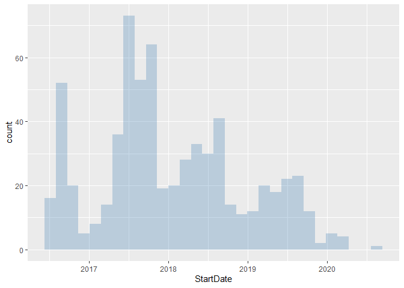

```r
ggplot(data = df_clean[which(is.na(df_clean$StartLatitude) | is.na(df_clean$EndLatitude)), ],
       aes(x = StartDate)) +
  geom_histogram(fill = alpha("steelblue", 0.3))
```

Looks like the NA values in latitude and longitude happened somewhat randomly; I don’t think they are missing systematically. Also, there just aren’t that many missing. I think we can remove them.

```r
df_clean = df_clean[which(!is.na(df_clean$StartLatitude) & !is.na(df_clean$EndLatitude)), ]
```

That change removed another 656 trips.

Check the summary again:

```r
summary(df_clean)
```

```
##     RouteID         PaymentPlan          StartHub         StartLatitude
##  Min.   : 1282087   Length:1287289     Length:1287289     Min.   :45.37
##  1st Qu.: 3708338   Class :character   Class :character   1st Qu.:45.52
##  Median : 7598890   Mode  :character   Mode  :character   Median :45.52
##  Mean   : 7502600                                         Mean   :45.52
##  3rd Qu.:11377648                                         3rd Qu.:45.53
##  Max.   :13531535                                         Max.   :45.68
##  StartLongitude     StartDate           StartTime           EndHub
##  Min.   :-123.1   Min.   :2016-07-19   Length:1287289    Length:1287289
##  1st Qu.:-122.7   1st Qu.:2017-07-21   Class1:hms        Class :character
##  Median :-122.7   Median :2018-06-16   Class2:difftime   Mode  :character
##  Mean   :-122.7   Mean   :2018-06-06   Mode  :numeric
##  3rd Qu.:-122.7   3rd Qu.:2019-05-10
##  Max.   :-122.4   Max.   :2020-08-31
##   EndLatitude     EndLongitude       EndDate             EndTime
##  Min.   :45.35   Min.   :-123.1   Min.   :2016-07-19   Length:1287289
##  1st Qu.:45.52   1st Qu.:-122.7   1st Qu.:2017-07-21   Class1:hms
##  Median :45.52   Median :-122.7   Median :2018-06-16   Class2:difftime
##  Mean   :45.52   Mean   :-122.7   Mean   :2018-06-06   Mode  :numeric
##  3rd Qu.:45.53   3rd Qu.:-122.7   3rd Qu.:2019-05-10
##  Max.   :45.70   Max.   :-122.4   Max.   :2020-09-01
##    TripType             BikeID        BikeName         Distance_Miles
##  Length:1287289     Min.   : 5986   Length:1287289     Min.   : 0.000
##  Class :character   1st Qu.: 6302   Class :character   1st Qu.: 0.720
##  Mode  :character   Median : 6574   Mode  :character   Median : 1.310
##                     Mean   : 6982                      Mean   : 1.847
##                     3rd Qu.: 7155                      3rd Qu.: 2.410
##                     Max.   :35537                      Max.   :14.990
##    Duration         RentalAccessPath   MultipleRental
##  Length:1287289     Length:1287289     Mode :logical
##  Class :character   Class :character   FALSE:1168188
##  Mode  :character   Mode  :character   TRUE :119101
##
##
##
```

Save the new file to an rds file:

```r
#saveRDS(df_clean, file = "Biketown_clean.rds")
```